# Kelp Rockfish

*Sebastes atrovirens*

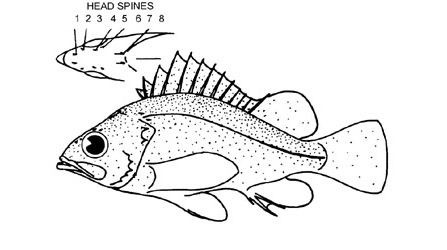

**Body color:** Dark-olive gray to olive-brown, darker w/ mottling, fins same color as body.

**Peritoneum color:** light **Shape between eyes:** convex

**Counts:** D:XIII,13-15, Ar:6-7, P1:16-18, GR:28-34, LLp:36-45, LLs:?-?, V:2

**Occurence:** Northern California - Baja California

**Depth:** 46 meters **Size:** 43 cm **Species code:** 30070

**Similar species:**

- *Grass rockfish* - gillrakers short and stubby, 17-25 (28-34 not short in Kelp RF); pectoral fin does not reach vent (reaches vent in Kelp RF); head spine count typically differs; body green (olive-brown in Kelp RF)
- *Brown rockfish* - dark blotch on operculum (absent in Kelp RF); head spines 6 and 8 typically present
- *Gopher rockfish* - body mottled w/ light areas; gillrakers 26-30 (typically 31-34 in Kelp RF)

Back to Group

**Corrections:** If you see mistakes or want to suggest changes, please create an [issue](https://github.com/zoyafuso-NOAA/RACE_Survey_App/issues) on the source repository or

*reach out to Liz Dawson (Liz.Dawson AT noaa.gov).*